# PA1_template

## Loading and preprocessing the data

First, we need to set work directory and local language, load the data. We’d like to see the summary of data.

```r
setwd("G:/DataAnalysis//repdata")
Sys.setlocale(category="LC_TIME",local="USA")
act <- read.csv("activity.csv")
summary(act)
```

[output not shown]

The type of date values is `Factor`, which has to be transformed to `Date`.

```r
act$date <- as.Date(act$date)
```

## What is mean total number of steps taken per day?

We use ggplot2 to make the histogram of the total number of steps taken each day. If you don’t have it, use `install.packages("ggplot2")` to install.

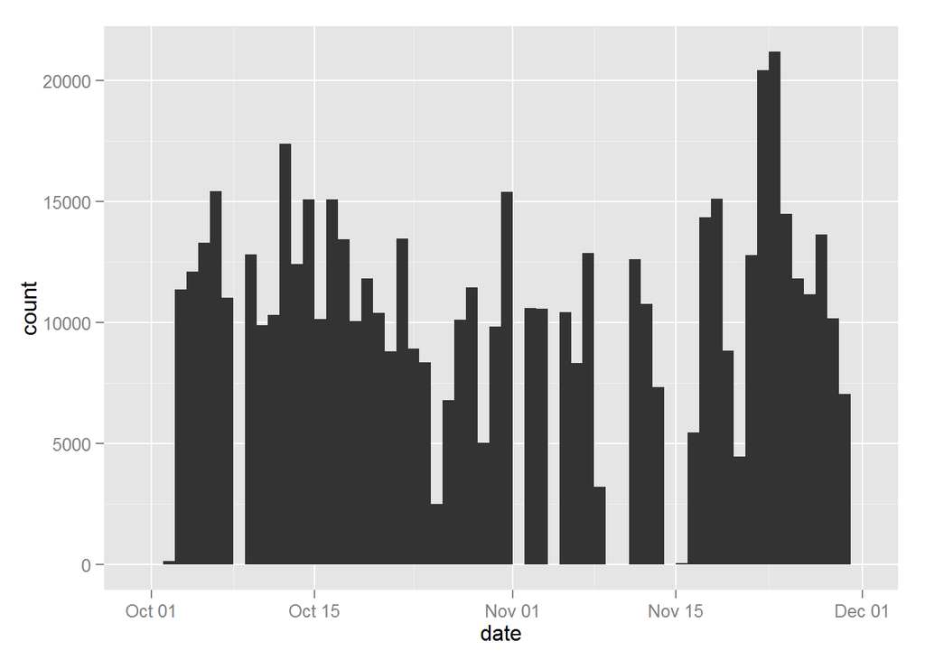

```r
library(ggplot2)
qplot(date, data = act, weight = steps, geom = "histogram", binwidth = 1)
```

```r
steps.by.day <- with(act,
                     aggregate(steps, list(date),
                               function(x) sum(x, na.rm = TRUE)))
names(steps.by.day) <- c("date", "total")
mea <- mean(steps.by.day$total)
med <- median(steps.by.day$total)
```

the **mean** total number of steps taken per day: 9354.2295082  
the **median** total number of steps taken per day: 10395

## What is the average daily activity pattern?

Let’s make a time series plot of the 5-minute interval (x-axis) and the average number of steps taken, averaged across all days (y-axis). We also compute the maximum number of the averaged across all the days.

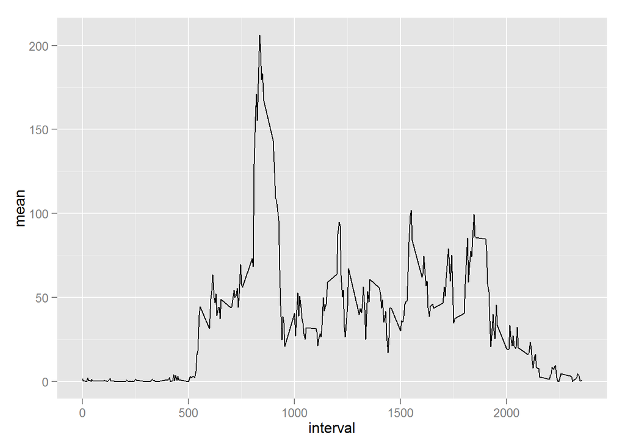

```r
steps.by.interval <- with(act,
            aggregate(steps, list(interval),
               function(x) mean(x, na.rm = TRUE)))
names(steps.by.interval) <- c("interval", "mean")
max.avg <- max(steps.by.interval$mean)
max.int <- steps.by.interval[steps.by.interval$mean == max.avg, "interval"]
qplot(interval, mean, data = steps.by.interval, geom = "line")
```

We could see most steps taken between interval 500 and 2000, the peak comes at interval 835, and the maximum number is 206.1698113.

## Imputing missing values

```
## [1] 2304
```

We have calculated the total number of steps taken by day. When reading the data we could find that it’s `NA` on 1 Oct, 2012.

```
##         date total
## 1 2012-10-01     0
## 2 2012-10-02   126
## 3 2012-10-03 11352
## 4 2012-10-04 12116
## 5 2012-10-05 13294
## 6 2012-10-06 15420
```

It suggests that the data of steps might be `NA` of all the intervals in one day. We cannot calculate the mean or median of that day. So, we are going to fill the `NA`s with the average steps by interval across all these days.

```r
library(dplyr)
new.act <- arrange(act, date)
naData <- filter(new.act, is.na(steps))
naData <- merge(naData, steps.by.interval, by = "interval", all = FALSE)
naData <- arrange(naData, date)
new.act[is.na(new.act$steps), "steps"] <- naData$mean
```

We use package `dplyr` to make the data match. Again, we draw the histogram of the steps take by day, and calculate the **mean** and **median**.

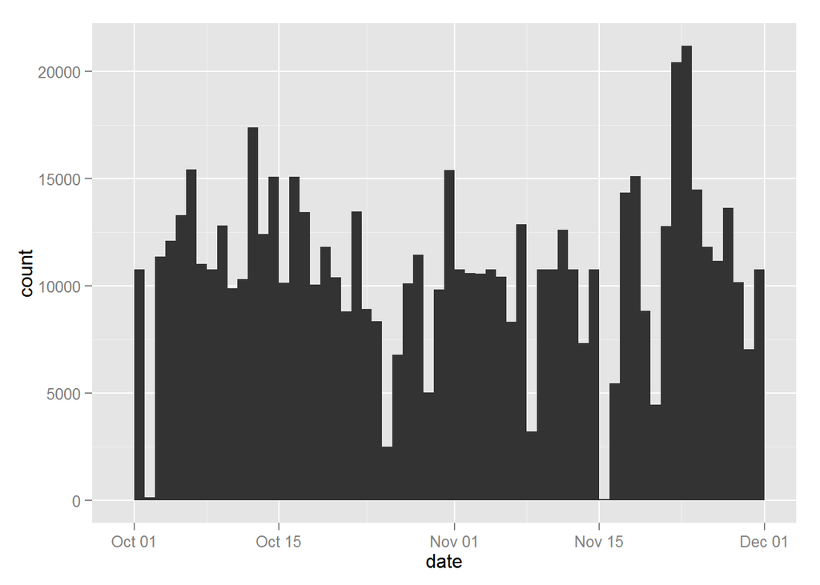

```r
qplot(date, data = new.act, weight = steps, geom = "histogram",
      binwidth = 1)
```

```r
steps.by.day <- with(new.act,
                     aggregate(steps, list(date),
                               function(x) sum(x, na.rm = TRUE)))
names(steps.by.day) <- c("date", "total")
mea <- mean(steps.by.day$total)
med <- median(steps.by.day$total)
```

Both **mean** and **median** are greater than themselves used to be. When filling these missing values, the total daily number is closer to our guess other than it actually is.

## Are there differences in activity patterns between weekdays and weekends?

We create the factor variables to note if that day is weekend.

```r
new.act <- mutate(new.act,
                  weekends = as.factor(
                    ifelse(weekdays(date) %in% c("Saturday", "Sunday"),
                           "Weekend", "weekday")))
```

Now draw the panel plot containing a time series plot of the 5-minute interval (x-axis) and the average number of steps taken, averaged across all weekday days or weekend days (y-axis).

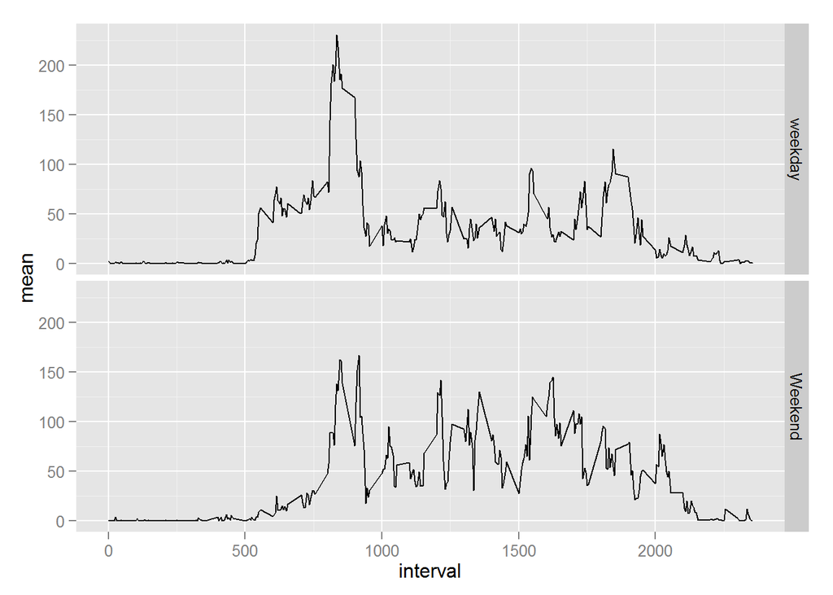

```r
steps.by.interval <- with(new.act,
            aggregate(steps, list(interval, weekends),
               function(x) mean(x, na.rm = TRUE)))
names(steps.by.interval) <- c("interval", "weekends", "mean")
qplot(interval, mean, data = steps.by.interval, geom = "line", facets =  weekends ~. )
```

The frequent activities start earlier in weekdays. The peak of the steps number dosen’t appear in weekends. There are more intervals in which number of steps are over 100 in weekends, between interval 1000 and 2000.